# act_report

## Caleb Newton

*DA Udacity Nanodegree Project 2 \ Jan, 2023*

## WeRateDogs Data

Data from 2356 of the 5000+ tweets from the @dog_rates twitter account that were published between November 15, 2015 and August 1, 2017 are included in the WeRateDogs Twitter archive. This information consists of dog ratings that were extracted from the tweet's text together with the dog's name and stage, if they were given. I had to obtain this additional information from the twitter account using the tweet ID from the archive because the retweet count and favorite count for each tweet were not included in the improved archive. I obtained an image predict file from Udacity servers that had the top 3 dog breed predictions based on the photographs from the tweets together with the Twitter data.

## Data Wrangling

In this project, data wrangling was grouped into 3 major steps, they are:

```
* Gathering Data
* Assessing Data
* Cleaning Data
```

**Gathering Data** As earlier stated, the 3 data files were obtained from WeRateDogs Twitter Archive, which i downloaded from the udacity page since i was having difficulties creating a developer account on twitter. The image_predict and json files were also obtained as earlier explained.

**Assessing Data** I assessed the data files programmatically and visually, pointing up a number of quality and organization problems that needed to be fixed. Visual Assessment found problems in the three data files, including repeating columns and non-descriptive column headers. Programmatic Assessment found the majority of the quality problems in the three data files, including inaccurate data types and duplicate data.

**Cleaning Data** I used the Define, Code, and Test framework to clean the data in a programmatic way. After translating my observations from the assess step into identified problems and writing complex code to address them, I tested the three datasets to ensure that the fixes were successful.The cleaned data files were combined, and I saved the result as a csv file (twitter archive master).

### Images from twitter

This is Sena.

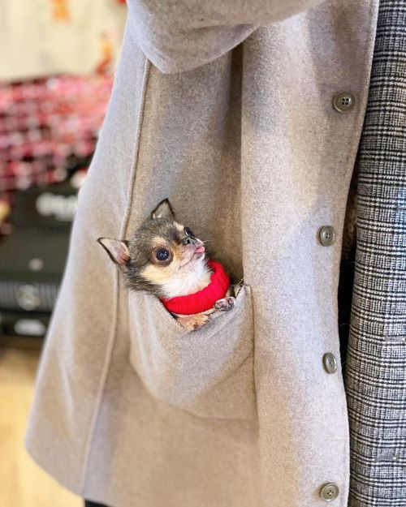

Screenshot of a recent upload by @dog_rates

[figure not shown]

## Insights

From the project, the following insights were created:

[output not shown]

## Visualization

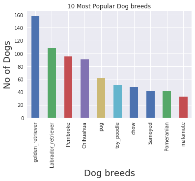

From the above chart, the following can be inferred:

```
* Golden retriever was the most popular dog breed
* Malamute was the least most popular amongst the top 10
```

Hence, it can be concluded that golden retriever happens to be loved more than other breeds

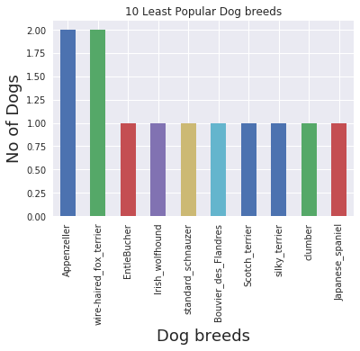

From the above chart, the following can be inferred:

[output not shown]

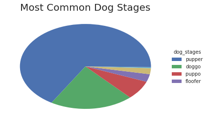